# Plant Disease Epidemiological Analysis Using Machine Learning

Jacobo Robledo

2024-10-23

# Introduction

In this analysis, we perform a plant disease epidemiological study using machine learning techniques. We use a dataset containing various environmental and soil properties to predict the **Level of Disease** in plants. The goal is to:

- Read a provided dataset in github
- Preprocess the data, including scaling and partitioning.
- Train multiple machine learning models for classification.
- Compare models based on accuracy and select the best ones.
- Perform hyperparameter tuning on the top models.
- Evaluate the final models and interpret the results.
- Visualize the confusion matrix and quantify feature importance.

# Data Preparation

We begin by loading the necessary libraries and importing the dataset.

```r
# You might need to install the following packages if you haven't already
# install.packages("caret")
# install.packages("e1071")
# install.packages("randomForest")
# install.packages("nnet")
# install.packages("rpart")
# install.packages("kknn")
# install.packages("MLmetrics")
# install.packages("kernlab")
# install.packages("tidyverse")
# install.packages("reshape2")

library(caret)         # For data splitting and model training
library(e1071)         # For SVM and Naive Bayes
library(randomForest)  # For Random Forest
library(nnet)          # For multinomial logistic regression
library(rpart)         # For Decision Trees
library(kknn)          # For k-NN
library(MLmetrics)     # For performance metrics
library(kernlab)       # For SVM kernels
library(tidyverse)     # For data manipulation and visualization
library(reshape2)      # For data reshaping

# Set seed for reproducibility
set.seed(123)

# Load the dataset
data <- read.csv("https://raw.githubusercontent.com/jrobledob/2024_PLP6905_ML_Class/refs/heads/main/disease_severity.csv")

# Ensure 'LevelOfDisease' is a factor
data$LevelOfDisease <- as.factor(data$LevelOfDisease)

# View the first few rows of the dataset
head(data)
```

```
##   Temperature Humidity  Rainfall WindSpeed SolarRadiation SoilMoisture
## 1    22.19762 41.17718  33.15028  9.127770       151.5105     46.61150
## 2    23.84911 40.11611  96.00831  2.735515       196.5343     80.00640
## 3    32.79354 40.44263 102.23008 11.139739       172.6100     98.83200
## 4    25.35254 66.01040  74.33825  6.317908       277.4675     64.80855
## 5    25.64644 64.49791 261.82766  1.612364       298.6845     50.91092
## 6    33.57532 73.14399  99.09533  2.382898       301.3489     29.63787
##   SoilTemperature AirPressure  DewPoint VaporPressureDeficit LeafWetness
## 1       24.527793    1026.107 27.825383            0.7352067   16.019680
## 2       26.726504    1022.020 13.066477            1.5988363    9.225598
## 3        8.801405    1009.286 19.441183            4.4336858    5.924469
## 4       29.513261    1015.598  6.971992            4.3493709   10.228284
## 5       17.335920    1026.813  7.105361            4.6469706   18.676424
## 6       14.531077    1015.329 21.069647            2.0802294    8.725824
##   CanopyTemperature Evapotranspiration   SoilpH SoilNitrogen SoilPhosphorus
```

[output cut: 62 more lines]

# Data Preprocessing

We preprocess the data by scaling the predictor variables and partitioning the dataset into training and testing sets.

```r
# Exclude 'LevelOfDisease' and 'Severity' from predictors
predictors <- data[, !(names(data) %in% c("LevelOfDisease", "Severity"))]

# Scale the predictor variables
preProcValues <- preProcess(predictors, method = c("center", "scale"))
predictorsScaled <- predict(preProcValues, predictors)

# Combine scaled predictors with the target variable
dataScaled <- cbind(predictorsScaled, LevelOfDisease = data$LevelOfDisease)

# Stratified partitioning of the dataset into training and testing sets (80/20 split)
trainIndex <- createDataPartition(dataScaled$LevelOfDisease, p = 0.8, list = FALSE)
trainData <- dataScaled[trainIndex, ]
testData <- dataScaled[-trainIndex, ]
```

# Model Training

We set up cross-validation and train five different machine learning models to predict the **Level of Disease**.

```r
# Set up cross-validation with 3 groups
train_control <- trainControl(
  method = "cv",
  number = 3,
  classProbs = TRUE,
  summaryFunction = multiClassSummary,
  savePredictions = TRUE
)

# List to store models
models <- list()

# 1. Multinomial Logistic Regression
set.seed(123)
model_multinom <- train(
  LevelOfDisease ~ ., data = trainData,
  method = "multinom",
  trControl = train_control,
  trace = FALSE
)
models$Multinom <- model_multinom

# 2. Decision Tree
set.seed(123)
model_rpart <- train(
  LevelOfDisease ~ ., data = trainData,
  method = "rpart",
  trControl = train_control
)
models$DecisionTree <- model_rpart

# 3. Random Forest
set.seed(123)
model_rf <- train(
  LevelOfDisease ~ ., data = trainData,
  method = "rf",
  trControl = train_control
)
models$RandomForest <- model_rf

# 4. Support Vector Machine
set.seed(123)
model_svm <- train(
  LevelOfDisease ~ ., data = trainData,
  method = "svmLinear",
  trControl = train_control
)
models$SVM <- model_svm

# 5. k-Nearest Neighbors
set.seed(123)
model_knn <- train(
  LevelOfDisease ~ ., data = trainData,
  method = "knn",
  trControl = train_control,
  tuneLength = 10
)
models$kNN <- model_knn
```

# Model Evaluation

We compare the models based on their cross-validation accuracy and select the top two models.

```r
# Compare models using resamples
resamps <- resamples(models)
summary(resamps)
```

```
##
## Call:
## summary.resamples(object = resamps)
##
## Models: Multinom, DecisionTree, RandomForest, SVM, kNN
## Number of resamples: 3
##
## Accuracy
##                   Min.   1st Qu.    Median      Mean   3rd Qu.      Max. NA's
## Multinom     0.8352060 0.8467075 0.8582090 0.8566065 0.8673067 0.8764045    0
## DecisionTree 0.6367041 0.6373819 0.6380597 0.6858451 0.7104156 0.7827715    0
## RandomForest 0.8801498 0.8820225 0.8838951 0.8865224 0.8897088 0.8955224    0
## SVM          0.7865169 0.8052434 0.8239700 0.8117046 0.8242985 0.8246269    0
## kNN          0.4981273 0.5046607 0.5111940 0.5137189 0.5215146 0.5318352    0
##
## AUC
##                   Min.   1st Qu.    Median      Mean   3rd Qu.      Max. NA's
## Multinom     0.9698080 0.9713290 0.9728500 0.9746021 0.9769992 0.9811484    0
## DecisionTree 0.7916716 0.7944164 0.7971613 0.8321550 0.8523968 0.9076322    0
## RandomForest 0.9861655 0.9866296 0.9870937 0.9868883 0.9872497 0.9874057    0
## SVM          0.9471660 0.9527367 0.9583075 0.9568799 0.9617369 0.9651664    0
## kNN          0.7464810 0.7510910 0.7557010 0.7632838 0.7716852 0.7876693    0
##
## Kappa
##                   Min.   1st Qu.    Median      Mean   3rd Qu.      Max. NA's
## Multinom     0.7646069 0.7812236 0.7978402 0.7953196 0.8106760 0.8235117    0
## DecisionTree 0.4524640 0.4534628 0.4544615 0.5304645 0.5694647 0.6844679    0
## RandomForest 0.8271915 0.8299305 0.8326696 0.8367055 0.8414625 0.8502554    0
## SVM          0.7060607 0.7319921 0.7579236 0.7410139 0.7584905 0.7590573    0
## kNN          0.2283736 0.2378469 0.2473201 0.2521195 0.2639924 0.2806647    0
##
## logLoss
##                   Min.   1st Qu.    Median      Mean   3rd Qu.      Max. NA's
## Multinom     0.8096067 0.8134528 0.8172988 0.9222655 0.9785948 1.1398908    0
## DecisionTree 0.6266542 0.7499932 0.8733323 0.8293975 0.9307692 0.9882061    0
## RandomForest 0.3000194 0.3030350 0.3060506 0.3098596 0.3147797 0.3235089    0
## SVM          0.5640903 0.5759413 0.5877923 0.5875660 0.5993039 0.6108155    0
## kNN          1.0483438 1.1263401 1.2043365 1.2318123 1.3235465 1.4427565    0
##
## Mean_Balanced_Accuracy
```

[output cut: 63 more lines]

```
## Mean_Specificity
##                   Min.   1st Qu.    Median      Mean   3rd Qu.      Max. NA's
## Multinom     0.9403955 0.9451112 0.9498268 0.9485873 0.9526832 0.9555396    0
## DecisionTree 0.8602534 0.8604306 0.8606079 0.8794347 0.8890254 0.9174429    0
## RandomForest 0.9553404 0.9557365 0.9561326 0.9574197 0.9584594 0.9607862    0
## SVM          0.9291398 0.9366355 0.9441311 0.9392835 0.9443554 0.9445796    0
## kNN          0.8059695 0.8081334 0.8102973 0.8115232 0.8143001 0.8183029    0
##
## prAUC
##                   Min.   1st Qu.    Median      Mean   3rd Qu.      Max. NA's
## Multinom     0.8618943 0.8843795 0.9068648 0.8929734 0.9085130 0.9101611    0
## DecisionTree 0.1192248 0.1213694 0.1235141 0.1870947 0.2210297 0.3185453    0
## RandomForest 0.9422141 0.9457824 0.9493507 0.9487017 0.9519456 0.9545404    0
## SVM          0.8565675 0.8692868 0.8820061 0.8807155 0.8927895 0.9035729    0
## kNN          0.4673236 0.4825540 0.4977844 0.5040652 0.5224360 0.5470876    0
```

```r
# Extract accuracy metrics and compute 95% confidence intervals
accuracy_results <- resamps$values
model_names <- names(models)

# Function to compute mean accuracy and 95% confidence intervals
getMeanCI <- function(x) {
  n <- length(x)
  mean_x <- mean(x)
  sd_x <- sd(x)
  error <- qt(0.975, df = n - 1) * sd_x / sqrt(n)
  lower <- mean_x - error
  upper <- mean_x + error
  return(c(Mean = mean_x, LowerCI = lower, UpperCI = upper))
}

# Initialize results dataframe
results <- data.frame(
  Model = character(),
  MeanAccuracy = numeric(),
  LowerCI = numeric(),
  UpperCI = numeric(),
  stringsAsFactors = FALSE
)

# Calculate accuracy and confidence intervals for each model
for (model_name in model_names) {
  acc <- resamps$values[[paste0(model_name, "~Accuracy")]]
  stats <- getMeanCI(acc)
  results <- rbind(results, data.frame(
    Model = model_name,
    MeanAccuracy = round(stats["Mean"], 4),
    LowerCI = round(stats["LowerCI"], 4),
    UpperCI = round(stats["UpperCI"], 4)
  ))
}

# Display the comparative table
print(results)
```

```
##              Model MeanAccuracy LowerCI UpperCI
## Mean      Multinom       0.8566  0.8053  0.9079
## Mean1 DecisionTree       0.6858  0.4773  0.8944
## Mean2 RandomForest       0.8865  0.8666  0.9064
## Mean3          SVM       0.8117  0.7575  0.8659
## Mean4          kNN       0.5137  0.4715  0.5559
```

```r
# Select the best two models based on MeanAccuracy
top_models <- results[order(-results$MeanAccuracy), ][1:2, ]
print("Top 2 Models:")
```

```
## [1] "Top 2 Models:"
```

```r
print(top_models)
```

```
##              Model MeanAccuracy LowerCI UpperCI
## Mean2 RandomForest       0.8865  0.8666  0.9064
## Mean      Multinom       0.8566  0.8053  0.9079
```

**Interpretation:**

- The models are compared based on cross-validation accuracy.
- The Random Forest and Multinomial Logistic Regression models are identified as the top two models.

# Hyperparameter Tuning for the Best Models

We perform hyperparameter tuning on the top two models to improve their performance.

```r
# -------------------------
# Hyperparameter Tuning
# -------------------------

# 1. Hyperparameter Tuning for Random Forest
# Define the tuning grid for mtry
rf_grid <- expand.grid(
  .mtry = seq(2, ncol(predictorsScaled), by = 5)  # Adjust the sequence as needed
)

set.seed(123)
model_rf_tuned <- train(
  LevelOfDisease ~ ., data = trainData,
  method = "rf",
  trControl = train_control,
  tuneGrid = rf_grid,
  importance = TRUE,
  ntree = 500  # You can adjust the number of trees
)

# 2. Hyperparameter Tuning for Multinomial Logistic Regression
# Define the tuning grid for decay
multinom_grid <- expand.grid(
  .decay = c(0, 0.001, 0.01, 0.1, 0.5, 1)
)

set.seed(123)
model_multinom_tuned <- train(
  LevelOfDisease ~ ., data = trainData,
  method = "multinom",
  trControl = train_control,
  tuneGrid = multinom_grid,
  trace = FALSE,
  maxit = 500  # Increase iterations if needed
)
```

**Explanation:**

- **Random Forest:** We tune the `mtry` parameter, which is the number of variables randomly sampled as candidates at each split.
- **Multinomial Logistic Regression:** We tune the `decay` parameter, which is the regularization parameter to prevent overfitting.

# Evaluating the Tuned Models

We evaluate the performance of the tuned models on the test set.

```r
# -------------------------
# Evaluate on Test Set
# -------------------------

# Predictions using the best Random Forest model
rf_predictions <- predict(model_rf_tuned, newdata = testData)
rf_confusion <- confusionMatrix(rf_predictions, testData$LevelOfDisease)
print("Random Forest Test Set Performance:")
```

```
## [1] "Random Forest Test Set Performance:"
```

```r
print(rf_confusion)
```

```
## Confusion Matrix and Statistics
##
##           Reference
## Prediction absent high low medium
##     absent     20    0   1      0
##     high        0   25   0      1
##     low         5    0  65      4
##     medium      0    4   4     69
##
## Overall Statistics
##
##                Accuracy : 0.904
##                  95% CI : (0.8542, 0.9412)
##     No Information Rate : 0.3737
##     P-Value [Acc > NIR] : < 2.2e-16
##
##                   Kappa : 0.8609
##
##  Mcnemar's Test P-Value : NA
##
## Statistics by Class:
##
##                      Class: absent Class: high Class: low Class: medium
## Sensitivity                 0.8000      0.8621     0.9286        0.9324
## Specificity                 0.9942      0.9941     0.9297        0.9355
## Pos Pred Value              0.9524      0.9615     0.8784        0.8961
## Neg Pred Value              0.9718      0.9767     0.9597        0.9587
## Prevalence                  0.1263      0.1465     0.3535        0.3737
## Detection Rate              0.1010      0.1263     0.3283        0.3485
## Detection Prevalence        0.1061      0.1313     0.3737        0.3889
## Balanced Accuracy           0.8971      0.9281     0.9291        0.9340
```

```r
# Predictions using the best Multinomial Logistic Regression model
multinom_predictions <- predict(model_multinom_tuned, newdata = testData)
multinom_confusion <- confusionMatrix(multinom_predictions, testData$LevelOfDisease)
print("Multinomial Logistic Regression Test Set Performance:")
```

```
## [1] "Multinomial Logistic Regression Test Set Performance:"
```

```r
print(multinom_confusion)
```

```
## Confusion Matrix and Statistics
##
##           Reference
## Prediction absent high low medium
##     absent     23    0   4      0
##     high        0   22   0      5
##     low         2    0  64      2
##     medium      0    7   2     67
##
## Overall Statistics
##
##                Accuracy : 0.8889
##                  95% CI : (0.8366, 0.929)
##     No Information Rate : 0.3737
##     P-Value [Acc > NIR] : < 2.2e-16
##
##                   Kappa : 0.8408
##
##  Mcnemar's Test P-Value : NA
##
## Statistics by Class:
##
##                      Class: absent Class: high Class: low Class: medium
## Sensitivity                 0.9200      0.7586     0.9143        0.9054
## Specificity                 0.9769      0.9704     0.9688        0.9274
## Pos Pred Value              0.8519      0.8148     0.9412        0.8816
## Neg Pred Value              0.9883      0.9591     0.9538        0.9426
## Prevalence                  0.1263      0.1465     0.3535        0.3737
## Detection Rate              0.1162      0.1111     0.3232        0.3384
## Detection Prevalence        0.1364      0.1364     0.3434        0.3838
## Balanced Accuracy           0.9484      0.8645     0.9415        0.9164
```

**Interpretation:**

- We generate predictions on the test data using the tuned models.
- Confusion matrices are printed to evaluate the models’ performance.

# Compiling Final Results

We compile the cross-validation and test set performance metrics into a comparison table.

```r
# -------------------------
# Extract Performance Metrics
# -------------------------

# Function to extract CV metrics
extract_cv_metrics <- function(model, model_name, tune_param) {
  # Get the best tuning parameters
  best_params <- model$bestTune

  # Filter results for the best parameters
  best_results <- model$results
  for (param in names(best_params)) {
    best_results <- best_results[best_results[[param]] == best_params[[param]], ]
  }

  # Extract metrics
  accuracy <- best_results$Accuracy
  kappa <- best_results$Kappa
  accuracy_sd <- best_results$AccuracySD
  kappa_sd <- best_results$KappaSD

  # Compile into a data frame
  cv_metrics <- data.frame(
    Model = model_name,
    Metric = c("Accuracy (CV)", "Kappa (CV)"),
    Mean = c(accuracy, kappa),
    SD = c(accuracy_sd, kappa_sd),
    stringsAsFactors = FALSE
  )
  return(cv_metrics)
}

# Extract CV metrics for Random Forest
cv_metrics_rf <- extract_cv_metrics(model_rf_tuned, "Random Forest", "mtry")

# Extract CV metrics for Multinomial Logistic Regression
cv_metrics_multinom <- extract_cv_metrics(model_multinom_tuned, "Multinomial Logistic Regression", "decay")

# Function to extract Test metrics
extract_test_metrics <- function(conf_matrix, model_name) {
  accuracy <- conf_matrix$overall['Accuracy']
  kappa <- conf_matrix$overall['Kappa']

  test_metrics <- data.frame(
    Model = model_name,
    Metric = c("Accuracy (Test)", "Kappa (Test)"),
    Mean = as.numeric(c(accuracy, kappa)),
    SD = c(NA, NA),
    stringsAsFactors = FALSE
  )
  return(test_metrics)
}

# Extract Test metrics for Random Forest
test_metrics_rf <- extract_test_metrics(rf_confusion, "Random Forest")

# Extract Test metrics for Multinomial Logistic Regression
test_metrics_multinom <- extract_test_metrics(multinom_confusion, "Multinomial Logistic Regression")

# -------------------------
# Compile Final Results
# -------------------------

# Combine all metrics into a single data frame
final_results <- rbind(cv_metrics_rf, test_metrics_rf, cv_metrics_multinom, test_metrics_multinom)

# Format the table for better readability
final_results$Mean <- round(final_results$Mean, 4)
final_results$SD <- ifelse(is.na(final_results$SD), "-", round(final_results$SD, 4))

# Arrange the results for clarity
final_results <- final_results %>%
  arrange(factor(Model, levels = c("Random Forest", "Multinomial Logistic Regression")), Metric)

# Display the final comparison table
print(final_results)
```

```
##                             Model          Metric   Mean     SD
## 1                   Random Forest   Accuracy (CV) 0.8977 0.0152
## 2                   Random Forest Accuracy (Test) 0.9040      -
## 3                   Random Forest      Kappa (CV) 0.8528 0.0221
## 4                   Random Forest    Kappa (Test) 0.8609      -
## 5 Multinomial Logistic Regression   Accuracy (CV) 0.8641 0.0188
## 6 Multinomial Logistic Regression Accuracy (Test) 0.8889      -
## 7 Multinomial Logistic Regression      Kappa (CV) 0.8060 0.0272
## 8 Multinomial Logistic Regression    Kappa (Test) 0.8408      -
```

**Interpretation:**

- The Random Forest model outperforms the Multinomial Logistic Regression model in both cross-validation and test set performance.
- The higher accuracy and Kappa values indicate better predictive performance.

# Confusion Matrix for the Best Model

We generate and plot the confusion matrix for the Random Forest model.

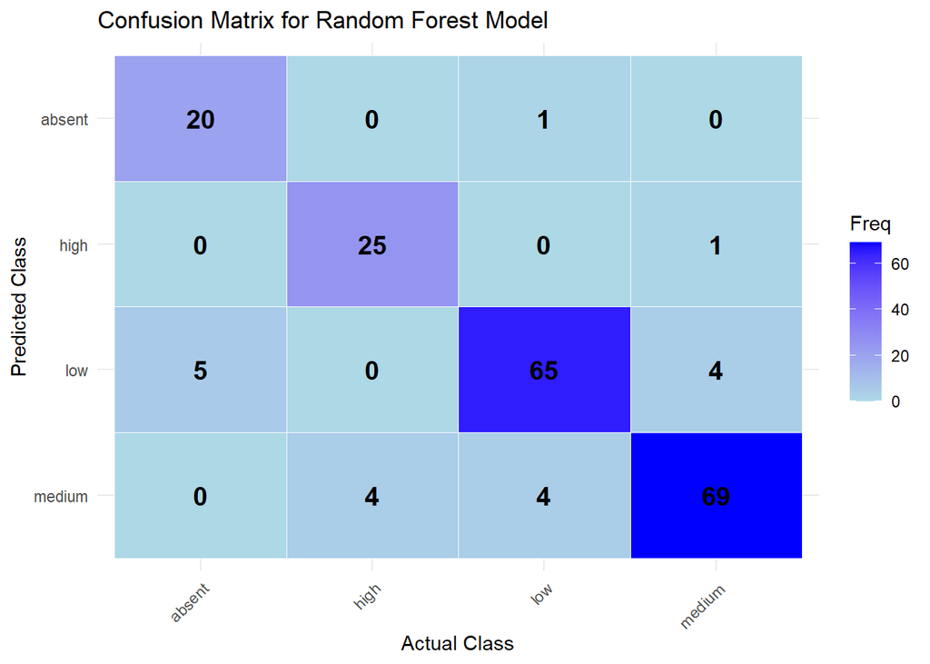

```r
# -------------------------
# Plot the Confusion Matrix
# -------------------------

# Extract confusion matrix table
cm_table <- rf_confusion$table

# Convert the table into a data frame
cm_df <- as.data.frame(cm_table)

# Rename columns for clarity
colnames(cm_df) <- c("Prediction", "Reference", "Freq")

# Ensure that the levels are in the correct order
cm_df$Prediction <- factor(cm_df$Prediction, levels = rev(levels(cm_df$Prediction)))
cm_df$Reference <- factor(cm_df$Reference, levels = levels(cm_df$Reference))

# Plot the confusion matrix using ggplot2
ggplot(data = cm_df, mapping = aes(x = Reference, y = Prediction, fill = Freq)) +
  geom_tile(color = "white") +
  geom_text(aes(label = Freq), vjust = 0.5, fontface = "bold", color = "black", size = 5) +
  scale_fill_gradient(low = "lightblue", high = "blue") +
  theme_minimal() +
  labs(title = "Confusion Matrix for Random Forest Model",
       x = "Actual Class",
       y = "Predicted Class") +
  theme(axis.text.x = element_text(angle = 45, hjust = 1))
```

**Visualization:**

- The confusion matrix heatmap provides a clear visual representation of the model’s classification performance.
- High values along the diagonal indicate correct classifications.

# Quantifying Feature Importance

We quantify the feature importance of the Random Forest model to understand which variables contribute most to the predictions.

```r
# -------------------------
# Feature Importance
# -------------------------

# Extract variable importance from the Random Forest model
# Extract variable importance from the Random Forest model without aggregation
var_imp <- varImp(model_rf_tuned, scale = TRUE, aggregate = FALSE)

# Convert varImp object to a data frame
var_imp_df <- as.data.frame(var_imp$importance)

# Add variable names as a column
var_imp_df$Variable <- rownames(var_imp_df)

# Compute the mean importance across all classes
var_imp_df$Overall <- rowMeans(var_imp_df[, -ncol(var_imp_df)])  # Exclude 'Variable' column

# Arrange variables by importance
var_imp_df <- var_imp_df %>%
  arrange(desc(Overall))

# Proceed with the rest of the code as before

# Display the top 10 most important variables
top_vars <- head(var_imp_df, 10)
print("Top 10 Important Variables:")
```

```
## [1] "Top 10 Important Variables:"
```

```r
print(top_vars)
```

```
##                         absent      high        low     medium
## SoilMoisture         79.031374 83.128189 100.000000 99.8377924
## Humidity             65.588360 70.641851  72.731771 75.0439381
## BacteriaCount         1.038959  6.181279   2.265645  5.7647009
## SoilAluminum          4.386999  3.236902   3.362978  4.0636680
## VaporPressureDeficit  4.600639  3.938699   1.887105  3.1095538
## SoilTemperature       1.779465  4.835437   2.805816  4.0462630
## SoilPorosity          4.927895  1.716209   2.261689  3.5851329
## SoilZinc              3.700003  2.988328   2.629896  3.0613792
## SoilNitrate           2.293182  2.427251   3.696631  3.5216445
## SoilChloride          3.303876  2.714415   4.876152  0.8658213
##                                  Variable   Overall
## SoilMoisture                 SoilMoisture 90.499339
## Humidity                         Humidity 71.001480
## BacteriaCount               BacteriaCount  3.812646
## SoilAluminum                 SoilAluminum  3.762637
## VaporPressureDeficit VaporPressureDeficit  3.383999
## SoilTemperature           SoilTemperature  3.366745
## SoilPorosity                 SoilPorosity  3.122732
## SoilZinc                         SoilZinc  3.094902
## SoilNitrate                   SoilNitrate  2.984677
## SoilChloride                 SoilChloride  2.940066
```

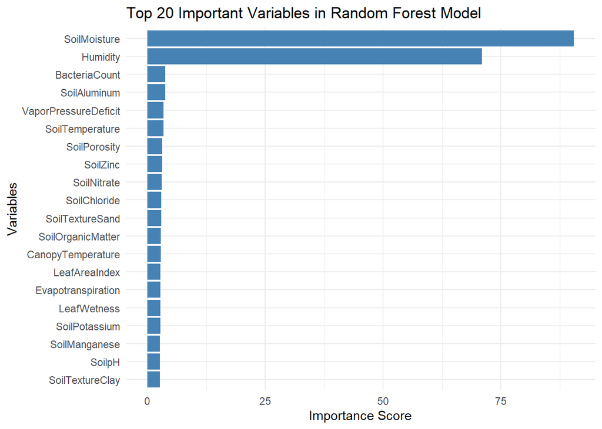

```r
# Plot the top 20 important variables
# Select the top 20 variables
top20_vars <- var_imp_df[1:20, ]

# Create the plot
ggplot(top20_vars, aes(x = reorder(Variable, Overall), y = Overall)) +
  geom_bar(stat = "identity", fill = "steelblue") +
  coord_flip() +
  theme_minimal() +
  labs(title = "Top 20 Important Variables in Random Forest Model",
       x = "Variables",
       y = "Importance Score")
```

**Interpretation:**

- The variable importance plot highlights the most influential predictors in the Random Forest model.
- Understanding these variables can provide insights into factors affecting disease levels.

# Conclusion

In this analysis, we successfully applied machine learning techniques to predict the **Level of Disease** in plants based on environmental and soil properties. The Random Forest model, after hyperparameter tuning, demonstrated superior performance. The feature importance analysis revealed key variables influencing disease severity, which can guide future research and practical applications in plant disease management.